# Global Earthquake Analysis - May 2025

Generated by ouRGeo / R

June 2025

# 1 Introduction

This report analyzes **global seismic activity** during May 2025 using real-time data from the **USGS Earthquake Hazards Program**. The dataset includes **2,022 earthquakes** of magnitude M2.5 and above recorded worldwide between May 1-31, 2025.

**Data source:** [USGS Earthquake Catalog API](https://earthquake.usgs.gov/earthquakes/feed/v1.0/csv.php)

# 2 1. Data Summary

```r
library(dplyr)

cat(sprintf("**Total earthquakes recorded:** %d (M2.5+)\n", nrow(eq_df)))
```

```
## **Total earthquakes recorded:** 2022 (M2.5+)
```

```r
cat(sprintf("**Date range:** %s to %s\n", min(eq_df$date), max(eq_df$date)))
```

```
## **Date range:** 2025-05-01 to 2025-05-31
```

```r
cat(sprintf("**Magnitude range:** %.1f to %.1f\n", min(eq_df$magnitude), max(eq_df$magnitude)))
```

```
## **Magnitude range:** 2.5 to 7.4
```

```r
cat(sprintf("**Mean magnitude:** %.2f (SD = %.2f)\n", mean(eq_df$magnitude), sd(eq_df$magnitude)))
```

```
## **Mean magnitude:** 3.92 (SD = 0.85)
```

```r
cat(sprintf("**Mean depth:** %.1f km\n", mean(eq_df$depth)))
```

```
## **Mean depth:** 64.0 km
```

```r
cat(sprintf("**Median magnitude:** %.1f\n", median(eq_df$magnitude)))
```

```
## **Median magnitude:** 4.2
```

```r
cat(sprintf("**Median depth:** %.1f km\n", median(eq_df$depth)))
```

```
## **Median depth:** 15.0 km
```

```r
max_idx <- which.max(eq_df$magnitude)
cat(sprintf("**Strongest earthquake:** M%.1f on %s - %s (depth: %.0f km)\n",
            eq_df$magnitude[max_idx], eq_df$date[max_idx],
            eq_df$place[max_idx], eq_df$depth[max_idx]))
```

```
## **Strongest earthquake:** M7.4 on 2025-05-02 - 2025 Drake Passage Earthquake (depth: 10 km)
```

```r
class_summary <- eq_df %>%
  count(mag_class) %>%
  arrange(desc(n)) %>%
  mutate(pct = sprintf("%.1f%%", 100 * n / nrow(eq_df)))

knitr::kable(class_summary, caption = "Earthquakes by Magnitude Class", align = "c")
```

Earthquakes by Magnitude Class

| mag_class | n | pct |
| --- | --- | --- |
| Moderate (M4.0-5.0) | 1085 | 53.7% |
| Minor (M2.5-3.0) | 436 | 21.6% |
| Light (M3.0-4.0) | 358 | 17.7% |
| Strong (M5.0-6.0) | 129 | 6.4% |
| Major (M6.0+) | 14 | 0.7% |

# 3 2. Global Earthquake Map

The map below shows the spatial distribution of all 2,022 earthquakes recorded in May 2025. Size and color encode magnitude class. The **Pacific Ring of Fire** is clearly visible as the dominant seismic zone.

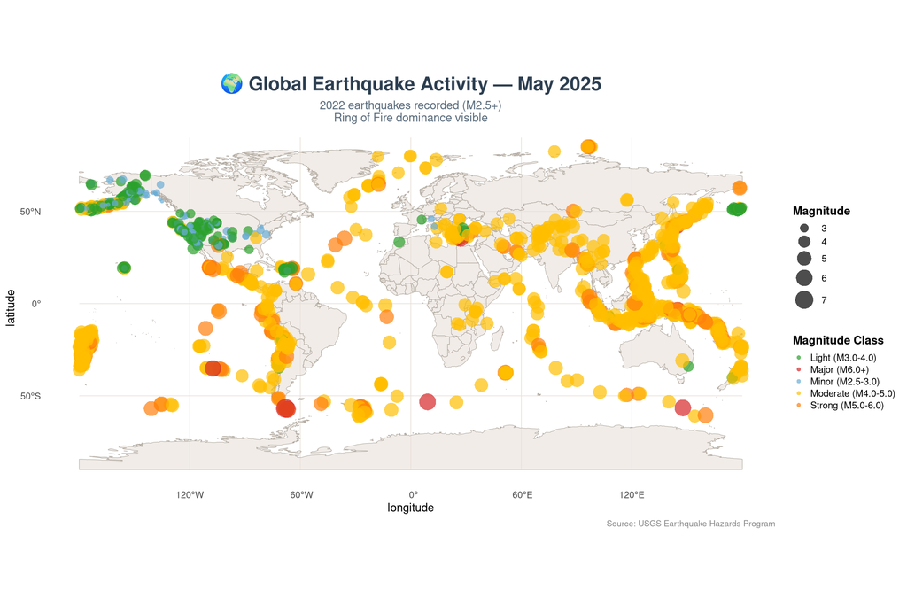

TRUE

```r
p1
```

**Key observations from the map:**

- The Pacific Ring of Fire dominates global seismicity, wrapping around the Pacific Ocean
- The Kermadec Islands region (near New Zealand) shows high concentration of moderate-to-strong events
- The Aleutian-Alaska arc (north of the Pacific) is highly active
- Mid-ocean ridges and the Alpine-Himalayan belt also show significant activity
- Most earthquakes occur within the first 100 km of the Earth surface